# Simulate Sehl, Friedman, & Denison 2022

In Sehl, Friedman, & Denison 2022, the authors find that people are more likely to infer friendship between two individuals if they share many mutual friends. Here, we try testing whether we can use multistep relational abstraction (via the Successor Representation) to simulate behavior reproducing the pattern of results found in the Sehl paper.

# Setup

```r
library(tidyverse)
library(here)
```

```r
library(patchwork)
library(tidygraph)
library(ggraph)

kable <- knitr::kable

knitting <- knitr::is_html_output()

workflow_name <- "06-sehl"

# Create directories for saving stuff
if (knitting) {
  if (!dir.exists(here("outputs", workflow_name))) {
    dir.create(here("outputs", workflow_name))
  }
}

gg <- list(
  theme_bw(),
  theme(
    plot.title = element_text(hjust = 0.5, size = 13),
    plot.subtitle = element_text(hjust = 0.5, size = 11),
    panel.grid.major = element_blank(),
    panel.grid.minor = element_blank(),
    panel.spacing = unit(0.75, "lines"),
    legend.box.spacing = unit(0.5, "lines"),
    legend.margin = margin(c(0, 0, 0, 0), unit = "lines")
  )
)

source(here("code", "utils", "modeling_utils.R"))
```

# The empirical study

Experiment 3 is the most useful for our purposes. Subjects observed that (e.g.) Sam and Dani have some number of friends, and some number of those friends are mutual friends. The total network size was always 24 individuals, and no other information was provided about other network members’ friendships.

In different (within-subject) conditions, Sam and Dani each had either 6 or 12 total friends. If they had 6 friends, 1, 3, or 5 were mutual friends. If they had 12 friends each, 2, 6, or 10 were mutual. Therefore, the ratios were kept constant at 1:6, 1:2, and 5:6.

Below, we reproduce Figure 3 from the paper.

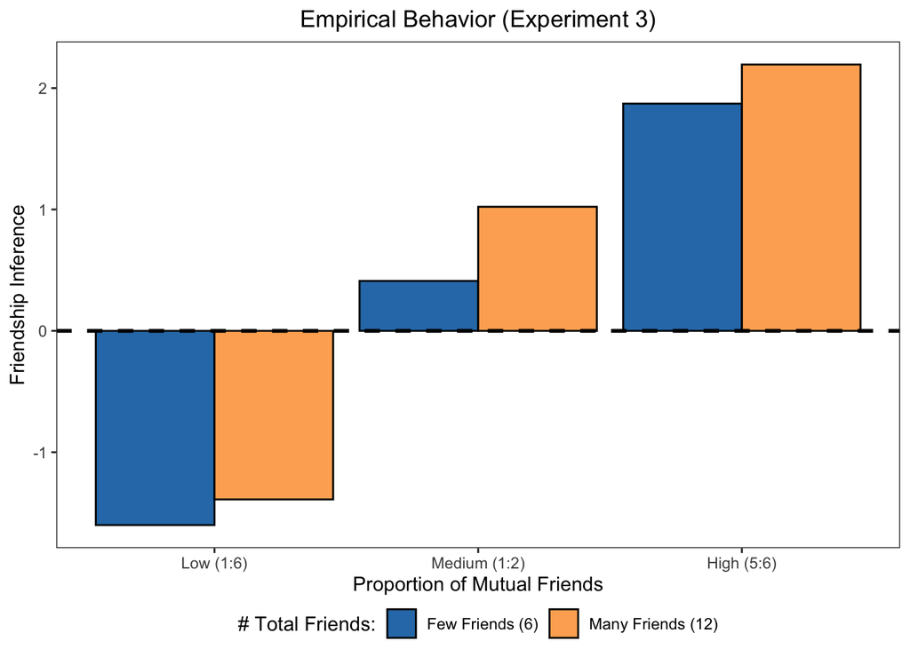

```r
sehl_exp3 <- here("data", "sehl", "Experiment 3 data.csv") %>%
  read_csv(show_col_types = FALSE) %>%
  arrange(subject) %>%
  mutate(
    n_friends = if_else(
      total_group == "few", "Few Friends (6)", "Many Friends (12)"
    ),
    mutual_prop = case_when(
      mutual == "low" ~ "Low (1:6)",
      mutual == "half" ~ "Medium (1:2)",
      mutual == "high" ~ "High (5:6)"
    ),
    mutual_prop = fct_relevel(mutual_prop, "Low (1:6)", "Medium (1:2)")
  )

plot_exp3 <- sehl_exp3 %>%
  group_by(n_friends, mutual_prop) %>%
  summarise(judgment = mean(response), .groups = "drop") %>%
  ggplot(aes(x=mutual_prop, y=judgment, fill=n_friends)) +
  gg +
  ggtitle("Empirical Behavior (Experiment 3)") +
  geom_col(color = "black", position = position_dodge()) +
  geom_hline(yintercept = 0, linetype = "dashed", size = 1) +
  scale_x_discrete(name = "Proportion of Mutual Friends") +
  scale_y_continuous(name = "Friendship Inference") +
  scale_fill_manual(
    name = "# Total Friends:", values = c("#2c7bb6", "#fdae61")
  ) +
  theme(legend.position = "bottom")

plot_exp3
```

# Simulate SRs

First, we need to recreate the networks used in the study.

```r
sehl_blank <- expand_grid(from = 1:26, to = from)

sehl_individual6_mutual1 <- sehl_blank %>%
  mutate(
    edge = case_when(
      # 1 and 2's mutual friends
      (from %in% 1:2) & (to %in% 3) ~ 1,
      (to %in% 1:2) & (from %in% 3) ~ 1,
      # 1's non-mutual friends
      (from == 1) & (to %in% 4:8) ~ 1,
      (to == 1) & (from %in% 4:8) ~ 1,
      # 2's non-mutual friends
      (from == 2) & (to %in% 9:13) ~ 1,
      (to == 2) & (from %in% 9:13) ~ 1,
      # Otherwise assume no friendship
      TRUE ~ 0
    ),
    individual = 6, mutual = 1
  )

sehl_individual6_mutual3 <- sehl_blank %>%
  mutate(
    edge = case_when(
      # 1 and 2's mutual friends
      (from %in% 1:2) & (to %in% 3:5) ~ 1,
      (to %in% 1:2) & (from %in% 3:5) ~ 1,
      # 1's non-mutual friends
      (from == 1) & (to %in% 6:8) ~ 1,
      (to == 1) & (from %in% 6:8) ~ 1,
      # 2's non-mutual friends
      (from == 2) & (to %in% 9:11) ~ 1,
      (to == 2) & (from %in% 9:11) ~ 1,
      # Otherwise assume no friendship
      TRUE ~ 0
    ),
    individual = 6, mutual = 3
  )

sehl_individual6_mutual5 <- sehl_blank %>%
  mutate(
    edge = case_when(
      # 1 and 2's mutual friends
      (from %in% 1:2) & (to %in% 3:7) ~ 1,
      (to %in% 1:2) & (from %in% 3:7) ~ 1,
      # 1's non-mutual friends
      (from == 1) & (to %in% 8) ~ 1,
      (to == 1) & (from %in% 8) ~ 1,
      # 2's non-mutual friends
      (from == 2) & (to %in% 9) ~ 1,
      (to == 2) & (from %in% 9) ~ 1,
      # Otherwise assume no friendship
      TRUE ~ 0
    ),
    individual = 6, mutual = 5
  )

sehl_individual12_mutual2 <- sehl_blank %>%
  mutate(
    edge = case_when(
      # 1 and 2's mutual friends
      (from %in% 1:2) & (to %in% 3:4) ~ 1,
      (to %in% 1:2) & (from %in% 3:4) ~ 1,
      # 1's non-mutual friends
      (from == 1) & (to %in% 5:14) ~ 1,
      (to == 1) & (from %in% 5:14) ~ 1,
      # 2's non-mutual friends
      (from == 2) & (to %in% 15:24) ~ 1,
      (to == 2) & (from %in% 15:24) ~ 1,
      # Otherwise assume no friendship
      TRUE ~ 0
    ),
    individual = 12, mutual = 2
  )

sehl_individual12_mutual6 <- sehl_blank %>%
  mutate(
    edge = case_when(
      # 1 and 2's mutual friends
      (from %in% 1:2) & (to %in% 3:8) ~ 1,
      (to %in% 1:2) & (from %in% 3:8) ~ 1,
      # 1's non-mutual friends
      (from == 1) & (to %in% 9:14) ~ 1,
      (to == 1) & (from %in% 9:14) ~ 1,
      # 2's non-mutual friends
      (from == 2) & (to %in% 15:20) ~ 1,
      (to == 2) & (from %in% 15:20) ~ 1,
      # Otherwise assume no friendship
      TRUE ~ 0
    ),
    individual = 12, mutual = 6
  )

sehl_individual12_mutual10 <- sehl_blank %>%
  mutate(
    edge = case_when(
      # 1 and 2's mutual friends
      (from %in% 1:2) & (to %in% 3:12) ~ 1,
      (to %in% 1:2) & (from %in% 3:12) ~ 1,
      # 1's non-mutual friends
      (from == 1) & (to %in% 13:14) ~ 1,
      (to == 1) & (from %in% 13:14) ~ 1,
      # 2's non-mutual friends
      (from == 2) & (to %in% 15:16) ~ 1,
      (to == 2) & (from %in% 15:16) ~ 1,
      # Otherwise assume no friendship
      TRUE ~ 0
    ),
    individual = 12, mutual = 10
  )

sehl_networks <- bind_rows(
  sehl_individual6_mutual1,
  sehl_individual6_mutual3,
  sehl_individual6_mutual5,
  sehl_individual12_mutual2,
  sehl_individual12_mutual6,
  sehl_individual12_mutual10
)
```

Just to get a visual sense, let’s plot a sample network. Subjects were asked to guess whether Red and Blue are friends, given their mutual friends (yellows) and exclusive friends (greys). In this example, Red and Blue have 12 friends each, 6 of whom are mutual.

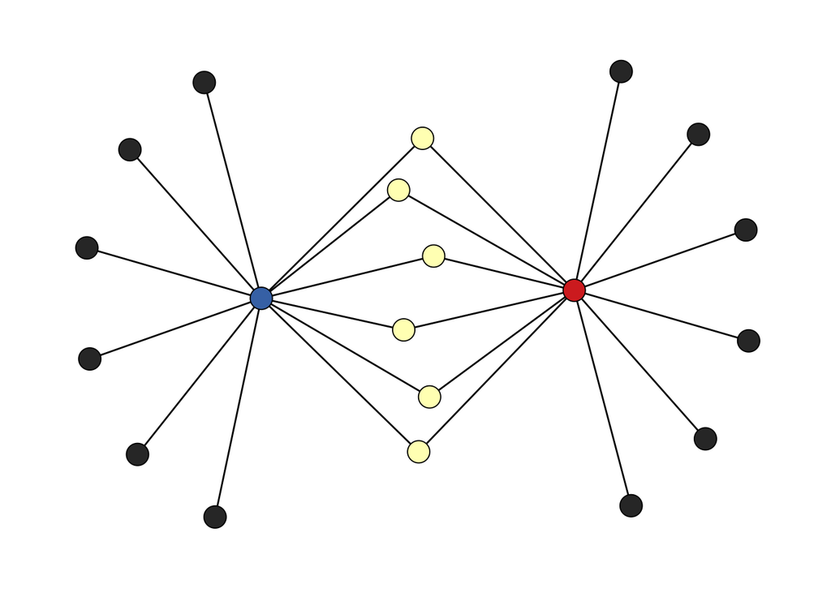

```r
plot_sample_network <- sehl_individual12_mutual6 %>%
  filter(edge == 1) %>%
  filter(from < to) %>%
  select(from, to) %>%
  tbl_graph(edges = ., directed = FALSE) %>%
  mutate(
    name = row_number(),
    color_group = case_when(
      name == 1 ~ "a",
      name == 2 ~ "b",
      name %in% 3:8 ~ "c",
      TRUE ~ "d"
    )
  ) %>%
  ggraph(layout = "stress") +
  theme_graph() +
  geom_edge_link() +
  geom_node_point(
    shape = 21,
    aes(fill = color_group), show.legend = FALSE, size = 6
  ) +
  scale_fill_manual(values = c("#d73027", "#4575b4", "#ffffbf", "grey20"))

plot_sample_network
```

Now we can use those to simulate SRs at a different gammas. Instead of training an SR via reinforcement learning, we’re using an analytical version. We do this because subjects in this study did no learning; they simply observed a single “slice” through the network, then made judgments. The use of an analytical SR is more mechanistically descriptive of this kind of representation.

```r
compute_sr <- function(df, sr_gamma) {
  trans_matrix <- df %>%
    select(from, to, edge) %>%
    group_by(from) %>%
    mutate(
      edge = edge / sum(edge),
      edge = if_else(is.nan(edge), 0, edge)
    ) %>%
    ungroup() %>%
    pivot_wider(names_from = to, values_from = edge) %>%
    select(-from) %>%
    as.matrix()

  # 24 = number of nodes in network
  sr <- solve(diag(26) - (sr_gamma * trans_matrix)) %>%
    data.frame() %>%
    mutate(from = row_number()) %>%
    pivot_longer(-from, names_to = "to") %>%
    mutate(
      to = str_remove(to, "X"),
      mutate(across(c(from, to), as.integer)),
      # Normalize SR values
      value = value / (1 / (1 - sr_gamma))
    )

  return(sr)
}
```

```r
sehl_sr_sim <- sehl_networks %>%
  expand_grid(gamma = seq(0.1, 0.9, 0.1)) %>%
  group_by(individual, mutual, gamma) %>%
  nest() %>%
  mutate(
    simulated = map2(
      .x = data,
      .y = gamma,
      .f = ~compute_sr(.x, .y)
    )
  ) %>%
  ungroup() %>%
  unnest(simulated) %>%
  select(-data) %>%
  # Most of SR is redundant, keep only informative info
  filter(from == 1 & to %in% 2:3) %>%
  mutate(
    target = if_else(to == 2, "Unknown Inference", "Known Friend"),
    mutual_prop = case_when(
      mutual / individual == 1/6 ~ "Low (1:6)",
      (mutual / individual == 3/6) & individual != 10 ~ "Medium (1:2)",
      mutual / individual == 5/6 ~ "High (5:6)"
    ),
    mutual_prop = fct_relevel(mutual_prop, "Low (1:6)", "Medium (1:2)"),
    n_friends = case_when(
      individual == 6 ~ "Few Friends (6)",
      individual == 10 ~ "Many Friends (10)",
      individual == 12 ~ "Many Friends (12)"
    )
  )
```

# Visualize simulations

First, let’s try plotting the raw SR values. This visualization demonstrates two things. First, given the information made available to subjects in the Sehl et al study, the SR value between Sam and Dani only depends on the *proportion* of mutual friends. Second, the SR value for a *known* friend only depends on the total number of friends Sam and Dani each have.

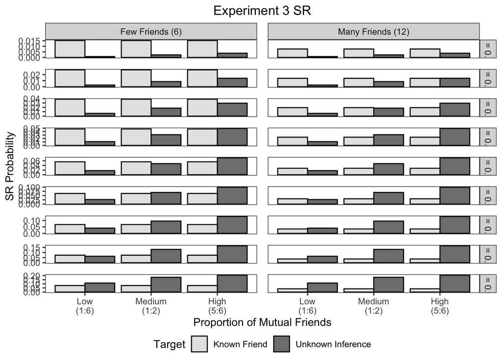

```r
sehl_sr_sim %>%
  mutate(gamma = str_c("\u03B3 = ", gamma)) %>%
  ggplot(aes(x=mutual_prop, y=value, fill=target)) +
  gg +
  ggtitle("Experiment 3 SR") +
  facet_grid(
    rows = vars(gamma),
    cols = vars(n_friends),
    scales = "free_y"
  ) +
  geom_col(color = "black", position = position_dodge()) +
  scale_x_discrete(
    name = "Proportion of Mutual Friends",
    labels = ~str_wrap(.x, width = 5)
  ) +
  scale_y_continuous(name = "SR Probability") +
  scale_fill_manual(name = "Target", values = c("grey90", "grey50")) +
  theme(legend.position = "bottom")
```

```r
if (knitting) {
  ggsave(
    here("outputs", workflow_name, "simulated-sr-probs.pdf"),
    width = 6, height = 8,
    device = cairo_pdf, units = "in", dpi = 300
  )
}
```

How might this translate into behavior? It’s a little bit tricky translating this into Likert scale ratings, so as a proxy, let’s just try to model the probability of inferring friendship between Sam and Dani. We assume an agent does this by comparing the Sam-to-Dani SR value against the Sam-to-known-friend / Dani-to-known friend SR value (in this study setup, they’re exactly the same), then making a binary “yes/no” judgment about whether Sam and Dani are friends. Mathematically, we’ll model this using a softmax comparing the SR values.

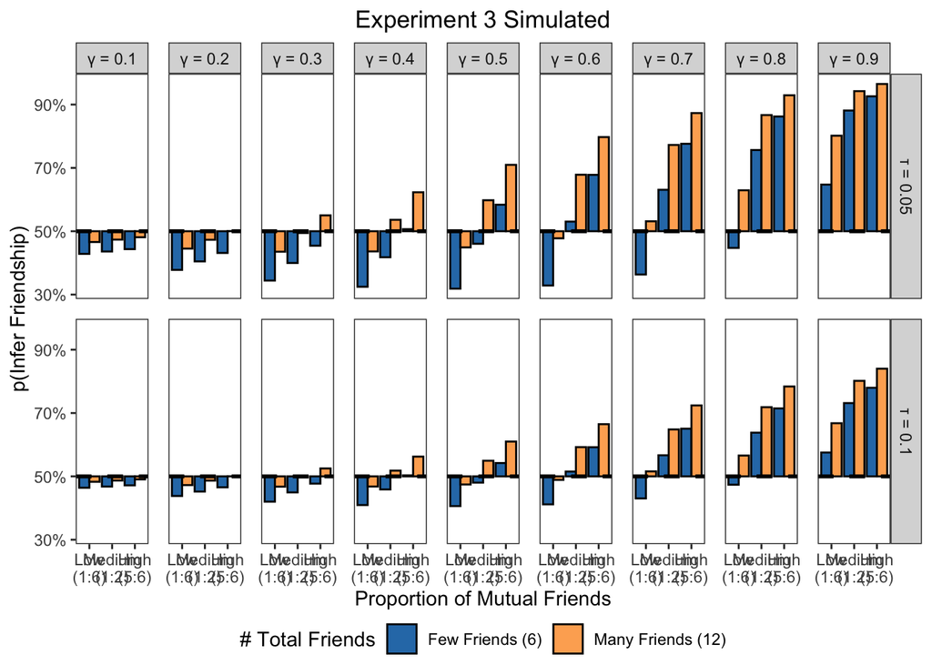

```r
sehl_sr_sim %>%
  expand_grid(softmax_temp = c(1/10, 1/20)) %>%
  select(softmax_temp, gamma, target, mutual_prop, n_friends, value) %>%
  pivot_wider(names_from = target) %>%
  rowwise() %>%
  mutate(
    p_infer = softmax(
      option_values = c(`Unknown Inference`, `Known Friend`),
      option_chosen = 1,
      temperature = softmax_temp
    ),
    # Plot distance from indifference point
    p_infer = p_infer - 0.5
  ) %>%
  ungroup() %>%
  select(softmax_temp, gamma, mutual_prop, n_friends, p_infer) %>%
  # Pretty plotting labels
  mutate(
    gamma = str_c("\u03B3 = ", gamma),
    softmax_temp = str_c("\u03C4 = ", softmax_temp)
  ) %>%
  ggplot(aes(x=mutual_prop, y=p_infer, fill=n_friends)) +
  gg +
  ggtitle("Experiment 3 Simulated") +
  facet_grid(
    cols = vars(gamma),
    rows = vars(softmax_temp)
  ) +
  geom_col(color = "black", position = position_dodge()) +
  geom_hline(yintercept = 0, linetype = "dashed", size = 1) +
  scale_x_discrete(
    name = "Proportion of Mutual Friends",
    labels = ~str_wrap(.x, width = 5)
  ) +
  scale_y_continuous(
    name = "p(Infer Friendship)",
    # Trick to relabel axis so that true-0 is labeled as 0.5=50%
    labels = ~scales::percent(.x + 0.5)
  ) +
  scale_fill_manual(
    name = "# Total Friends", values = c("#2c7bb6", "#fdae61")
  ) +
  theme(legend.position = "bottom")
```

```r
if (knitting) {
  ggsave(
    here("outputs", workflow_name, "simulated-choices.pdf"),
    width = 14, height = 8,
    device = cairo_pdf, units = "in", dpi = 300
  )
}
```

# Fit SR

Let’s try fitting the SR to subjects’ data. We’ll need an objective function…

```r
obj_fun <- function(param_values, param_names, fit_data, network_data) {
  # Assign variable names/values automatically
  for (j in 1:length(param_names)) {
    assign(param_names[j], param_values[j])
  }

  # Bound SR gamma to [0, 1)
  sr_gamma <- logistic_general(
    x = sr_gamma,
    lower_bound = 0,
    # SR becomes undefined when gamma = 1
    upper_bound = 0.99
  )

  model_predictions <- network_data %>%
    group_by(individual, mutual) %>%
    nest() %>%
    mutate(
      simulated = map2(
        .x = data,
        .y = sr_gamma,
        .f = ~compute_sr(.x, .y)
      )
    ) %>%
    ungroup() %>%
    unnest(simulated) %>%
    select(-data) %>%
    # Most of SR is redundant, keep only informative info
    filter(from == 1 & to %in% 2:3) %>%
    mutate(
      target = if_else(to == 2, "Unknown Inference", "Known Friend"),
      mutual_prop = case_when(
        mutual / individual == 1/6 ~ "Low (1:6)",
        (mutual / individual == 3/6) & individual != 10 ~ "Medium (1:2)",
        mutual / individual == 5/6 ~ "High (5:6)"
      ),
      mutual_prop = fct_relevel(mutual_prop, "Low (1:6)", "Medium (1:2)"),
      n_friends = case_when(
        individual == 6 ~ "Few Friends (6)",
        individual == 10 ~ "Many Friends (10)",
        individual == 12 ~ "Many Friends (12)"
      )
    ) %>%
    # Compute predicted probability of inferring friendship
    select(target, mutual_prop, n_friends, value) %>%
    pivot_wider(names_from = target) %>%
    rowwise() %>%
    mutate(
      p_infer = softmax(
        option_values = c(`Unknown Inference`, `Known Friend`),
        option_chosen = 1,
        temperature = softmax_tau
      )
    ) %>%
    ungroup() %>%
    select(mutual_prop, n_friends, p_infer)

  sum_neg_loglik <- fit_data %>%
    left_join(model_predictions, by = c("n_friends", "mutual_prop")) %>%
    mutate(
      likelihood = if_else(choice == 1, p_infer, 1 - p_infer),
      neg_ll = neg_loglik_logistic(likelihood)
    ) %>%
    summarise(neg_ll = sum(neg_ll)) %>%
    deframe()

  return(sum_neg_loglik)
}
```

It would take a long, long, long time to fit the model to each subject’s data: the optimization requires a costly matrix inversion, and it would take a while to run this even using the cluster. Since we’re primarily interested in knowing whether the model can replicate the group-level pattern, we’ll average over all subjects’ responses. To convert Likert scale responses into binary choices (for the sake of modeling), we’ll take the likelihood judgments (“how likely is it that these two people are friends?”) at face value: responses of -3 correspond to 0%, and responses of +3 correspond to 100%. We’ll then create 100 trials per condition, with an appropriate number of “yes they’re friends” responses based on the average likelihood rating in each condition.

```r
fit_data <- sehl_exp3 %>%
  mutate(
    response = response + abs(min(response)),
    p = response / max(response)
  ) %>%
  group_by(n_friends, mutual_prop) %>%
  summarise(p = round(mean(p), 2) * 100, .groups = "drop") %>%
  expand_grid(trial = 1:100) %>%
  mutate(choice = as.numeric(trial <= p))

# Set a random seed for reproducibility
set.seed(sum(utf8ToInt("sehl")))

# Run the optimizer a few times under different starting parameters
for (j in 1:5) {
  print(str_c("Starting run ", j))
  tryCatch(
    expr = {
      this_run <- run_optim(
        max_iter_per_run = 1000,
        objective_function = obj_fun,
        param_guesses = runif(2, -1, 1),
        param_names = c("sr_gamma", "softmax_tau"),
        # Supply arguments to objective function
        fit_data = fit_data,
        network_data = sehl_networks
      ) %>% mutate(optimizer_run = j)

      if (j == 1) {
        out <- this_run
      } else {
        out <- bind_rows(out, this_run)
      }
    },
    finally = {function(e) {warning(str_c("tryCatch error caught on run ", j))}}
  )
}
```

```
## [1] "Starting run 1"
## [1] "Starting run 2"
## [1] "Starting run 3"
```

```
## [1] "Starting run 4"
## [1] "Starting run 5"
```

```r
params <- best_optim_run(out, "dataframe") %>%
  mutate(
    param_value = if_else(
      param_name == "sr_gamma",
      logistic_general(param_value, 0, 0.99),
      param_value
    )
  ) %>%
  select(param_name, param_value) %>%
  pivot_wider(names_from = param_name, values_from = param_value)

params %>% kable()
```

| sr_gamma | softmax_tau |
| --- | --- |
| 0.5598269 | 0.0286306 |

# Visualize for paper

Alright, let’s visualize the model’s predictions and put together the figure for the paper.

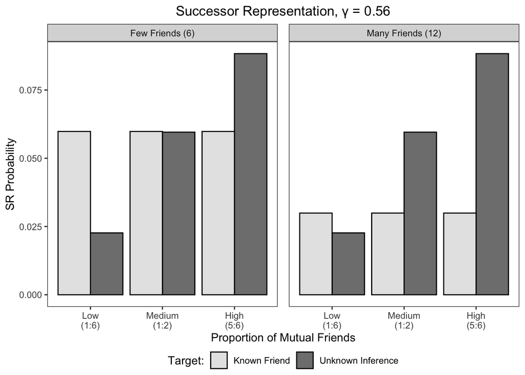

```r
sim_sr_values <- sehl_networks %>%
  group_by(individual, mutual) %>%
  nest() %>%
  mutate(
    simulated = map(
      .x = data,
      .f = ~compute_sr(.x, params$sr_gamma)
    )
  ) %>%
  ungroup() %>%
  unnest(simulated) %>%
  select(-data) %>%
  # Most of SR is redundant, keep only informative info
  filter(from == 1 & to %in% 2:3) %>%
  mutate(
    target = if_else(to == 2, "Unknown Inference", "Known Friend"),
    mutual_prop = case_when(
      mutual / individual == 1/6 ~ "Low (1:6)",
      (mutual / individual == 3/6) & individual != 10 ~ "Medium (1:2)",
      mutual / individual == 5/6 ~ "High (5:6)"
    ),
    mutual_prop = fct_relevel(mutual_prop, "Low (1:6)", "Medium (1:2)"),
    n_friends = case_when(
      individual == 6 ~ "Few Friends (6)",
      individual == 10 ~ "Many Friends (10)",
      individual == 12 ~ "Many Friends (12)"
    )
  )

plot_sr_values <- sim_sr_values %>%
  # Plot
  ggplot(aes(x=mutual_prop, y=value, fill=target)) +
  gg +
  ggtitle(
    str_c("Successor Representation, \u03B3 = ", round(params$sr_gamma, 2))
  ) +
  facet_grid(cols = vars(n_friends)) +
  geom_col(color = "black", position = position_dodge()) +
  scale_x_discrete(
    name = "Proportion of Mutual Friends",
    labels = ~str_wrap(.x, width = 5)
  ) +
  scale_y_continuous(name = "SR Probability") +
  scale_fill_manual(name = "Target:", values = c("grey90", "grey50")) +
  theme(legend.position = "bottom")

plot_choice <- sim_sr_values %>%
  select(target, mutual_prop, n_friends, value) %>%
  pivot_wider(names_from = target) %>%
  rowwise() %>%
  mutate(
    p_infer = softmax(
      option_values = c(`Unknown Inference`, `Known Friend`),
      option_chosen = 1,
      temperature = params$softmax_tau
    ),
    # Plot distance from indifference point
    p_infer = p_infer - 0.5
  ) %>%
  ungroup() %>%
  select(mutual_prop, n_friends, p_infer) %>%
  ggplot(aes(x=mutual_prop, y=p_infer, fill=n_friends)) +
  gg +
  ggtitle("Simulated Behavior (Experiment 3)") +
  geom_col(color = "black", position = position_dodge()) +
  geom_hline(yintercept = 0, linetype = "dashed", size = 1) +
  scale_x_discrete(name = "Proportion of Mutual Friends") +
  scale_y_continuous(
    name = "p(Infer Friendship)",
    # Trick to relabel axis so that true-0 is labeled as 0.5=50%
    labels = ~scales::percent(.x + 0.5)
  ) +
  scale_fill_manual(
    name = "# Total Friends:", values = c("#2c7bb6", "#fdae61")
  ) +
  theme(legend.position = "bottom")

figure_for_paper <- (plot_spacer() | plot_sample_network) / (plot_exp3 | plot_choice | plot_sr_values) +
  plot_annotation(
    title = str_c(
      "Inferring Relations from Mutual Friends ",
      "(Sehl, Friedman, & Denison 2022)"
    ),
    theme = theme(plot.title = element_text(hjust = 0.5, size = 15))
  ) +
  plot_layout(guides = "collect") &
  theme(
    legend.position = "bottom"
  )

plot_sr_values
```

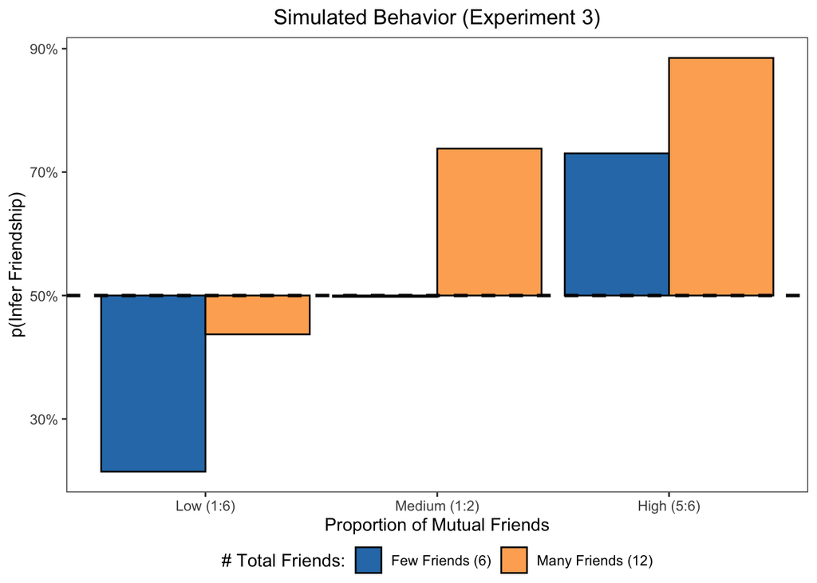

```r
plot_choice
```

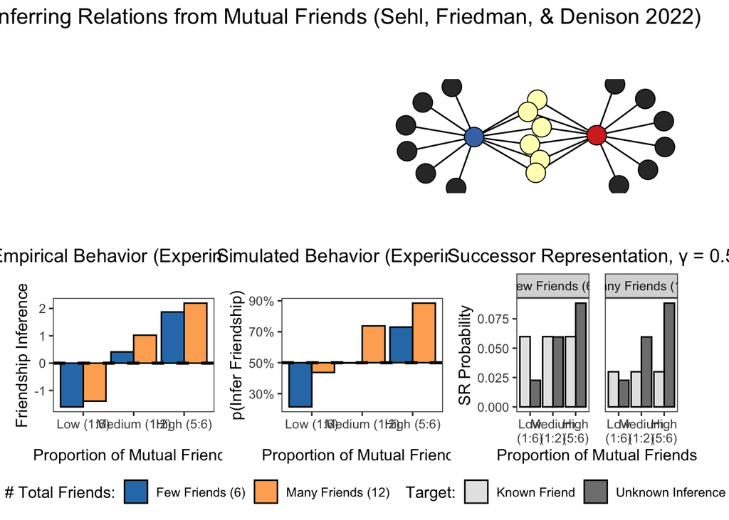

```r
figure_for_paper
```

```r
if (knitting) {
  ggsave(
    here("outputs", workflow_name, "sehl-2022.pdf"),
    figure_for_paper,
    width = 12, height = 8,
    device = cairo_pdf, units = "in", dpi = 300
  )
}
```